# writeup

It is common in the analysis of biological data to log transform data representing concentrations or data representing dose response. In this project, I will operate the log transform to different distributions and let’s see the results.

# Part 1

## Distribution 1

The first distribution we want to explore is the gamma distribution with shape parameter equal to 3 and scale parameter equal to 1.

Generate a figure of the PDF and CDF. Mark the mean and median in the figure.

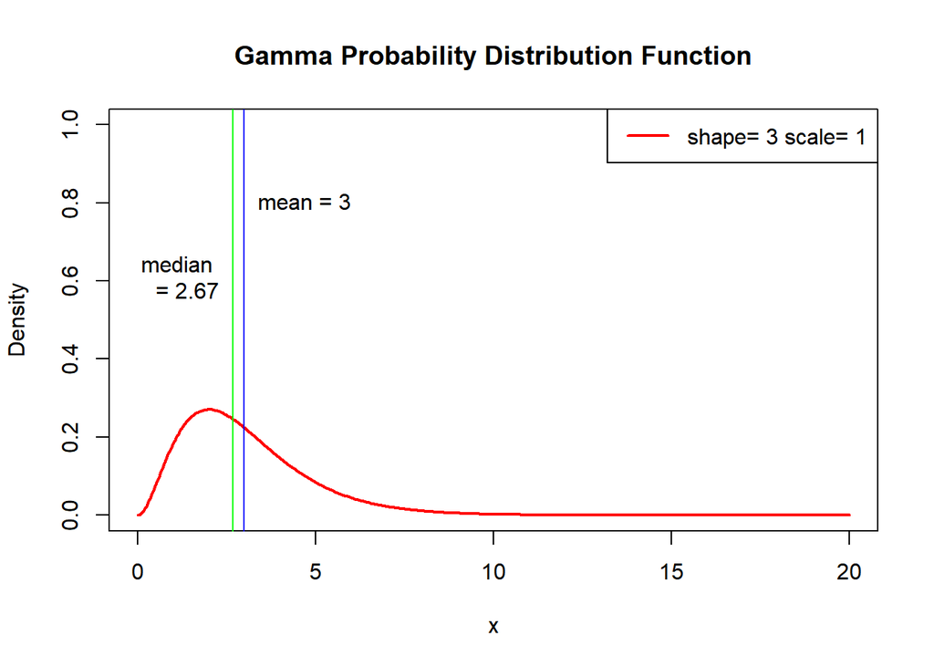

```r
# Probability distribution function
x = seq(0, 20, 0.05)
y = dgamma(x, shape = 3, scale = 1)

plot(x, y, main="Gamma Probability Distribution Function", ylab = "Density", xlim = c(0, 20), ylim = c(0, 1), col = "red", type = "l", lwd = 2)
legend("topright", legend = paste("shape=", 3, "scale=", 1), lwd = 2, col = "red")
abline(v = 3*1, col = "blue")
text(x = 3, y = 0.8, "mean = 3", pos = 4)
abline(v = qgamma(0.5, shape = 3, scale = 1), col = "green")
text(x = 2.67, y = 0.6, "median \n= 2.67", pos = 2)
```

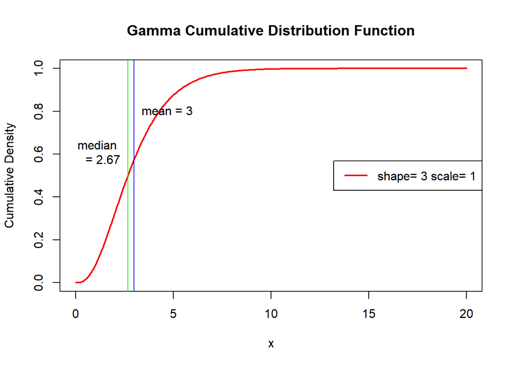

```r
# Cumulative distribution function
x = seq(0, 20, 0.05)
y = pgamma(x, shape = 3, scale = 1)

plot(x, y, main="Gamma Cumulative Distribution Function", ylab = "Cumulative Density", xlim = c(0, 20), ylim = c(0, 1), col = "red", type = "l", lwd = 2)
legend("right", legend = paste("shape=", 3, "scale=", 1), lwd = 2, col = "red")
abline(v = 3*1, col = "blue")
text(x = 3, y = 0.8, "mean = 3", pos = 4)
abline(v = qgamma(0.5, shape = 3, scale = 1), col = "green")
text(x = 2.67, y = 0.6, "median \n= 2.67", pos = 2)
```

Generate a figure of the PDF and CDF of the transformation Y = log(X) random variable. Mark the mean and median in the figure. You may use simulation or analytic methods in order find the PDF and CDF of the transformation.

I use the simulation method to find the PDF and CDF of the transformation.

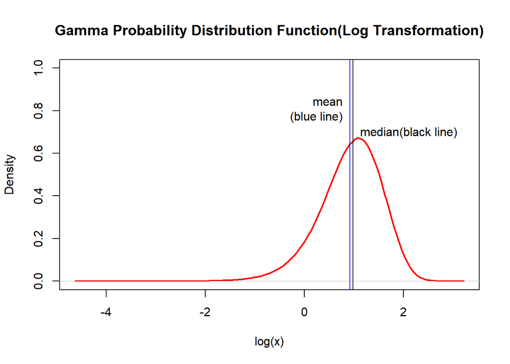

```r
# Probability distribution function
set.seed(1)
x = rgamma(1e6, shape = 3, scale = 1)
y = log(x)
plot(density(y), main = "Gamma Probability Distribution Function(Log Transformation)",  xlab = "log(x)", ylim = c(0, 1), col = "red", type = "l", lwd = 2)
abline(v = mean(y), col = "blue")
text(x = mean(y), y = 0.8, "mean\n(blue line)", pos = 2)
abline(v = median(y))
text(x = median(y), y = 0.7, "median(black line)", pos = 4)
```

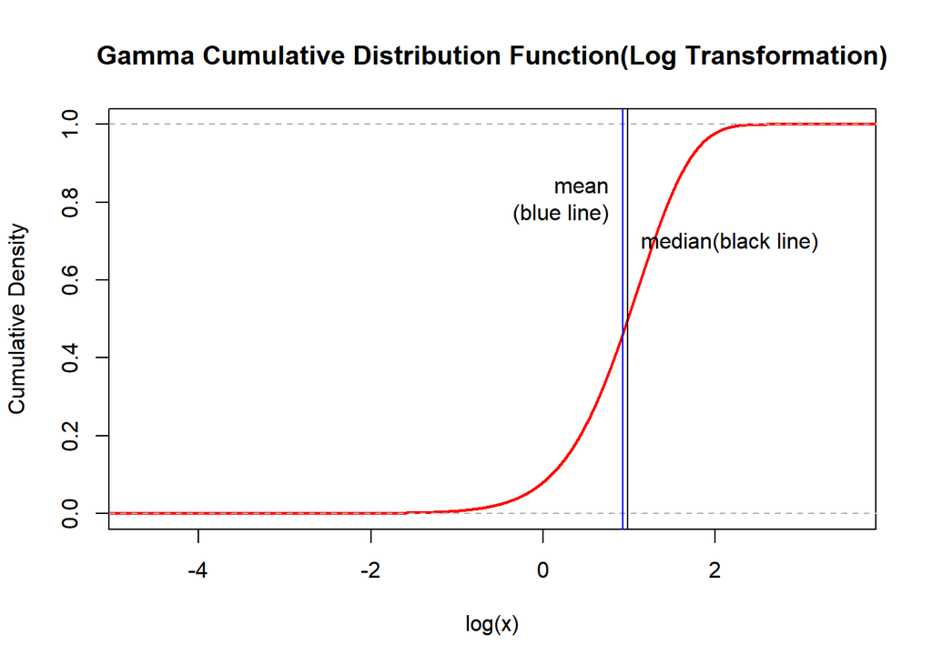

```r
# Cumulative distribution function
set.seed(2)
x = rgamma(1e6, shape = 3, scale = 1)
y = log(x)
plot(ecdf(y), main = "Gamma Cumulative Distribution Function(Log Transformation)", xlab = "log(x)", ylab = "Cumulative Density", ylim = c(0, 1), col = "red", lwd = 2)
abline(v = mean(y), col = "blue")
text(x = mean(y), y = 0.8, "mean\n(blue line)", pos = 2)
abline(v = median(y))
text(x = median(y), y = 0.7, "median(black line)", pos = 4)
```

Generate 1000 samples of size 100. For each sample, calculate the geometric and arithmetic mean. Generate a scatter plot of the geometic and arithmetic sample means. Add the line of identify as a reference line.

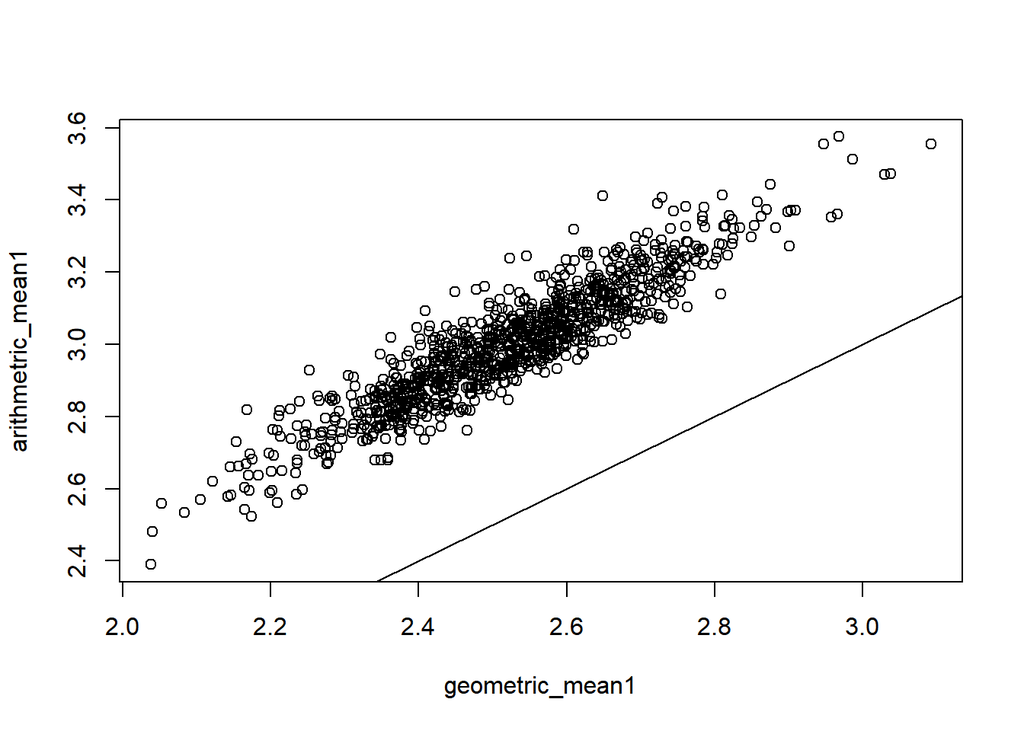

```r
x <- matrix(rgamma(1e5, shape = 3, scale = 1), nrow = 1000, ncol = 100)
geometric_mean <- function(x){
  exp(mean(log(x)))
}
geometric_mean1 <- apply(x, 1, geometric_mean)
arithmetric_mean1 <- apply(x, 1, mean)
plot(x = geometric_mean1, y = arithmetric_mean1)
abline(0, 1)
```

Generate a histogram of the difference between the arithmetic mean and the geometric mean

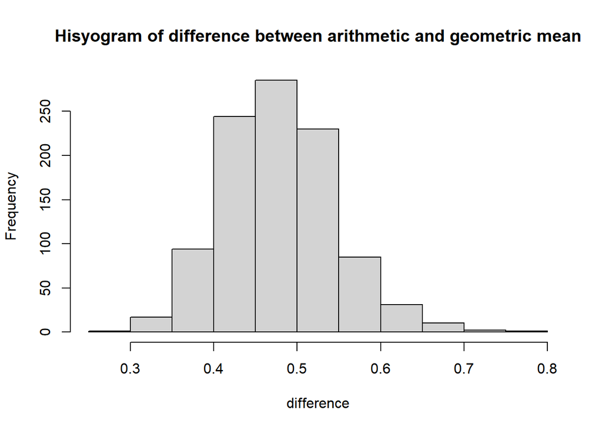

```r
difference <- arithmetric_mean1 - geometric_mean1
hist(difference, main = "Hisyogram of difference between arithmetic and geometric mean")
```